# Lab3

jche827

12/08/2021

# The Data Set

The data source for this lab is a set of 31 CSV files containing 15-minute vehicle counts from January 2013 to September 2020. The rows within these CSV files are similar to the rows in the CSV file from Lab Zero and Lab 01 ie. vehicle class, start time, end time, count etc. # Tasks

## 1. Write a shell command that shows the size of each of the 31 CSV files

```bash
# show sizes of all files ending with *TMSTrafficQuarterHour.csv in our directory
du -ah /course/NZTA/*TMSTrafficQuarterHour.csv
```

```
## 537M /course/NZTA/20130101_20130331_TMSTrafficQuarterHour.csv
## 532M /course/NZTA/20130401_20130630_TMSTrafficQuarterHour.csv
## 550M /course/NZTA/20130701_20130930_TMSTrafficQuarterHour.csv
## 535M /course/NZTA/20131001_20131231_TMSTrafficQuarterHour.csv
## 560M /course/NZTA/20140101_20140331_TMSTrafficQuarterHour.csv
## 562M /course/NZTA/20140401_20140630_TMSTrafficQuarterHour.csv
## 633M /course/NZTA/20140701_20140930_TMSTrafficQuarterHour.csv
## 576M /course/NZTA/20141001_20141231_TMSTrafficQuarterHour.csv
## 571M /course/NZTA/20150101_20150331_TMSTrafficQuarterHour.csv
## 590M /course/NZTA/20150401_20150630_TMSTrafficQuarterHour.csv
## 631M /course/NZTA/20150701_20150930_TMSTrafficQuarterHour.csv
## 606M /course/NZTA/20151001_20151231_TMSTrafficQuarterHour.csv
## 593M /course/NZTA/20160101_20160331_TMSTrafficQuarterHour.csv
## 599M /course/NZTA/20160401_20160630_TMSTrafficQuarterHour.csv
## 640M /course/NZTA/20160701_20160930_TMSTrafficQuarterHour.csv
## 631M /course/NZTA/20161001_20161231_TMSTrafficQuarterHour.csv
## 634M /course/NZTA/20170101_20170331_TMSTrafficQuarterHour.csv
## 681M /course/NZTA/20170401_20170630_TMSTrafficQuarterHour.csv
## 724M /course/NZTA/20170701_20170930_TMSTrafficQuarterHour.csv
## 698M /course/NZTA/20171001_20171231_TMSTrafficQuarterHour.csv
## 687M /course/NZTA/20180101_20180331_TMSTrafficQuarterHour.csv
## 724M /course/NZTA/20180401_20180630_TMSTrafficQuarterHour.csv
## 772M /course/NZTA/20180701_20180930_TMSTrafficQuarterHour.csv
## 758M /course/NZTA/20181001_20181231_TMSTrafficQuarterHour.csv
## 709M /course/NZTA/20190101_20190331_TMSTrafficQuarterHour.csv
## 712M /course/NZTA/20190401_20190630_TMSTrafficQuarterHour.csv
## 753M /course/NZTA/20190701_20190930_TMSTrafficQuarterHour.csv
## 754M /course/NZTA/20191001_20191231_TMSTrafficQuarterHour.csv
## 711M /course/NZTA/20200101_20200331_TMSTrafficQuarterHour.csv
## 707M /course/NZTA/20200401_20200630_TMSTrafficQuarterHour.csv
## 693M /course/NZTA/20200701_20200930_TMSTrafficQuarterHour.csv
```

## …and the total size of all 31 files

```bash
# find total size of 31 files
find /course/NZTA -type f -name '*_TMSTrafficQuarterHour.csv' -exec du -ch {} + | grep total$
```

```
## 20G  total
```

The total size of the 31 csv files in this directory is 20GB

## 2. Write a shell command that shows the amount of RAM available on one of the virtual machines.

```bash
free -g
```

```
##               total        used        free      shared  buff/cache   available
## Mem:            196          22           3           0         170         172
## Swap:            11           0          11
```

### How does this compare to Ubuntu?

Running the same line on the Ubuntu rstudio results in:

total = 15

used = 3

free = 8

shared = 0

buff/cache = 3

available = 11

Ubuntu only has ~15gb RAM total, but the VM has 196gb total RAM.

### how does this RAM amount compare to the csv files?

The csv files total 20gb, but the flexit Ubuntu computers only have 15gb in RAM, which is not enough to load all 31 csv files.

# Import

## 3. Read the first csv file and measure the size of the data frame that is created AND measure the total amount of memory that R used.

```r
library('profmem')
p1 <- profmem({
  # read the csv into our dataframe
  countsDF <- read.csv('/course/NZTA/20130101_20130331_TMSTrafficQuarterHour.csv')
})


head(countsDF)
```

```
##   class  siteRef     startDatetime       endDatetime direction count
## 1     H 01S00376 21-FEB-2013 04:15 21-FEB-2013 04:30         1   4.5
## 2     H 01S00376 23-FEB-2013 19:15 23-FEB-2013 19:30         2   4.5
## 3     H 01S00376 23-FEB-2013 23:30 23-FEB-2013 23:45         2   0.5
## 4     L 01S00376 24-FEB-2013 19:00 24-FEB-2013 19:15         2 122.0
## 5     L 01S00376 25-FEB-2013 00:45 25-FEB-2013 01:00         1   5.0
## 6     H 01S00376 25-FEB-2013 07:15 25-FEB-2013 07:30         2   6.5
```

```r
# find size of countsDF in mbs
print(object.size(countsDF), units = "Mb")
```

```
## 445.6 Mb
```

```r
# find memory usage in R
total(p1)
```

```
## [1] 2546771616
```

~2.5gb of memory used

## 4 Repeat the previous task using a data table and note any differences.

```r
library(data.table)
p2 <- profmem({
  # using a data table insted of a dataframe this time
  countsDT <- data.table::fread('/course/NZTA/20130101_20130331_TMSTrafficQuarterHour.csv')
})
head(countsDT)
```

```
##    class  siteRef     startDatetime       endDatetime direction count
## 1:     H 01S00376 21-FEB-2013 04:15 21-FEB-2013 04:30         1   4.5
## 2:     H 01S00376 23-FEB-2013 19:15 23-FEB-2013 19:30         2   4.5
## 3:     H 01S00376 23-FEB-2013 23:30 23-FEB-2013 23:45         2   0.5
## 4:     L 01S00376 24-FEB-2013 19:00 24-FEB-2013 19:15         2 122.0
## 5:     L 01S00376 25-FEB-2013 00:45 25-FEB-2013 01:00         1   5.0
## 6:     H 01S00376 25-FEB-2013 07:15 25-FEB-2013 07:30         2   6.5
```

```r
# find size of countsDT in mbs
print(object.size(countsDT), units = "Mb")
```

```
## 445.6 Mb
```

```r
# find memory usage in R
total(p2)
```

```
## [1] 512407000
```

~0.5 gb of memory used

These results tell us: both the dataframe and the data table are of object size 445.6 Mbs.

# Transform

## 5. Calculate daily counts from the 15-min counts in several different ways.

### naive “standard R” approach

```r
p3 <-  profmem({
# code from questions
countsDF$day <- as.Date(countsDF$startDatetime, format="%d-%b-%Y")
dailyCountsDF <- aggregate(countsDF["count"],
                           countsDF[c("day", "siteRef", "class")],
                           sum)
})
head(dailyCountsDF)
```

```
##          day  siteRef class  count
## 1 2013-01-01 00200002     H  737.5
## 2 2013-01-02 00200002     H 1214.5
## 3 2013-01-03 00200002     H 1757.0
## 4 2013-01-04 00200002     H 1861.5
## 5 2013-01-05 00200002     H 1361.0
## 6 2013-01-06 00200002     H 1126.5
```

```r
#find total memory used for naive standard R approach
total(p3)
```

```
## [1] 8575037400
```

~8.5gb used

### data table

```r
p4 <- profmem({
dailyCountsDT <- countsDT[, day := as.Date(startDatetime, format="%d-%b-%Y")][, sum(count), .(day, siteRef, class)]
})
head(dailyCountsDT)
```

```
##           day  siteRef class      V1
## 1: 2013-02-21 01S00376     H  1926.0
## 2: 2013-02-23 01S00376     H   901.5
## 3: 2013-02-24 01S00376     L 12360.5
## 4: 2013-02-25 01S00376     L  9858.5
## 5: 2013-02-25 01S00376     H  1729.5
## 6: 2013-02-26 01S00376     L  9399.0
```

```r
#find total memory used for data table apprach
total(p4)
```

```
## [1] 1232887256
```

~1.2gb of memory used

### shell script approach - memory used

```bash
/usr/bin/time -f "%M" \
awk -F, 'NR > 1 {gsub(/ .+/,"",$3); print $1","$2","$3", "$6}' /course/NZTA/20130101_20130331_TMSTrafficQuarterHour.csv | sort -t, -k1,1 -k2,2 -k3,3 | awk '{a[$1]+=$2}END{for (i in a) print i,a[i]}' > /dev/null
```

```
## 4188
```

~4000kbs memory used

## showing all 3 methods produce the same result

### number of rows in the dataframe

```r
dim(dailyCountsDF)
```

```
## [1] 72157     4
```

### number of rows in the data table

```r
dim(dailyCountsDT)
```

```
## [1] 72157     4
```

### number of rows from the bash command pipeline

```bash
awk -F, 'NR > 1 {gsub(/ .+/,"",$3); print $1","$2","$3", "$6}' /course/NZTA/20130101_20130331_TMSTrafficQuarterHour.csv | sort -t, -k1,1 -k2,2 -k3,3 | awk '{a[$1]+=$2}END{for (i in a) print i,a[i]}' | wc -l
```

```
## 72157
```

All 3 methods contain 72157 rows

### head of the sorted dataframe

```r
head(dailyCountsDF[order(dailyCountsDF$count),])
```

```
##              day  siteRef class count
## 21081 2013-02-11 07429020     H     0
## 21792 2013-01-14 08000001     H     0
## 22822 2013-03-24 09400240     H     0
## 16977 2013-01-23 01S60714     H     1
## 22743 2013-01-01 09400240     H     1
## 22751 2013-01-09 09400240     H     1
```

### head of the sorted data table

```r
head(dailyCountsDT[order(dailyCountsDT$V1),])
```

```
##           day  siteRef class V1
## 1: 2013-03-24 09400240     H  0
## 2: 2013-02-11 07429020     H  0
## 3: 2013-01-14 08000001     H  0
## 4: 2013-01-01 01N20424     L  1
## 5: 2013-01-01 09400240     H  1
## 6: 2013-01-09 09400240     H  1
```

### head of the sorted bash command pipeline

```bash
awk -F, 'NR > 1 {gsub(/ .+/,"",$3); print $1","$2","$3", "$6}' /course/NZTA/20130101_20130331_TMSTrafficQuarterHour.csv | sort -t, -k1,1 -k2,2 -k3,3 | awk '{a[$1]+=$2}END{for (i in a) print i,a[i]}' | sort -k2 -n| head
```

```
## H,07429020,11-FEB-2013, 0
## H,08000001,14-JAN-2013, 0
## H,09400240,24-MAR-2013, 0
## H,01S60714,23-JAN-2013, 1
## H,09400240,01-JAN-2013, 1
## H,09400240,09-JAN-2013, 1
## L,01N20424,01-JAN-2013, 1
## H,04300118,14-FEB-2013, 2
## H,07449006,14-JAN-2013, 2
## H,07469006,14-JAN-2013, 2
```

All methods show the same sorted head and number of rows, so we can assume they all produce the same result. Each of the methods produces the same head (with minor differences such as “V1” contains the counts for the data table, the order of columns in the shell script…)

# Model

## 7. Create a new variable scount that is the square-root of the count.

```r
dailyCountsDF$scount <- sqrt(dailyCountsDF$count)
head(dailyCountsDF)
```

```
##          day  siteRef class  count   scount
## 1 2013-01-01 00200002     H  737.5 27.15695
## 2 2013-01-02 00200002     H 1214.5 34.84968
## 3 2013-01-03 00200002     H 1757.0 41.91658
## 4 2013-01-04 00200002     H 1861.5 43.14510
## 5 2013-01-05 00200002     H 1361.0 36.89173
## 6 2013-01-06 00200002     H 1126.5 33.56337
```

## 8. Split the data into training (90%) and test (10%) sets and fit two models using the training data: one that predicts scount from the overall mean of scount and one that predicts scount from class.

### Defining the RMSE function

```r
RMSE <- function(obs, pred) {
  sqrt(mean((obs - pred)^2))
}
```

```r
# 10:90 test train split
index <- sample(rep(1:10, length.out=nrow(dailyCountsDF)))
test <- dailyCountsDF[index == 1,]
train <- dailyCountsDF[index > 1,]

# scount from overall mean of scount in training set
obs <- test$scount
p5 <- profmem({
smean <- mean(train$scount)
})

# scount from class
p6 <- profmem({
lmfit1 <- lm(scount ~ class, train)
})

sclass <- predict(lmfit1, test)
```

### Calculate the RMSE for both models.

Comparing the performance of these two models by their RMSE outputs.

```r
# RMSE value for scount from overall mean of scount
RMSE(obs, smean)
```

```
## [1] 56.62964
```

```r
# RMSE value of scount from class
RMSE(obs, sclass)
```

```
## [1] 44.98202
```

## Measure the memory allocated during the model fit and compare it to the size of the data.

```r
# memory usage fitting the scount with mean scounts
total(p5)
```

```
## [1] 23304
```

```r
# memory usage fitting the scount with class
total(p6)
```

```
## [1] 15449936
```

around 15mbs.

```r
# find size of the data
print(object.size(dailyCountsDF), units = "Mb")
```

```
## 2.8 Mb
```

The size of the data is ~3mbs

The memory allocated fitting the data with scount and class is 15mbs, which is around 5 times larger than the size of the data (~3mbs).

## 9. Calculate the size of the model matrix for the model with class as the predictor.

```r
print(object.size(model.matrix(lm(scount ~ class, train))), units = "Mb")
```

```
## 5 Mb
```

## Calculate the size of the model matrix for a model with class and siteRef as predictors. Can you explain why this is so much bigger than the model matrix with just class?

```r
p7 <- profmem({
lmfit2 <- lm(scount ~ class+siteRef, train)
})

total(p7)
```

```
## [1] 1453731736
```

~1.5gb

```r
# calculate model size
print(object.size(model.matrix(lm(scount ~ class+siteRef, train))), units = "Mb")
```

```
## 661.5 Mb
```

The model with siteref is so much bigger than the model matrix with just class due to siteref having many more different values compared to class. When we are only predicting on a model with class, there are only 2 classes (H and L). When we add siteref as a dimension, there will be hundreds-thousands more dimensions our linear model has to fit. This drastically increases the size and allocated memory from R.

## Describe an approach that would require less memory to perform that analysis.

To utilize less memory to perform the analysis, we can use the biglm function instead of lm(). The biglm package can be used to perform an analysisincrementally on chunks of data.

For example:

fit <- biglm(formula, someData)

update(fit, moreData)

fit <- bigglm(formula, dataFunction)

By splitting the data into chunks, we can perform the analysis while requiring less data.

## 11. Create a plot that shows the predictions of both models against the data.

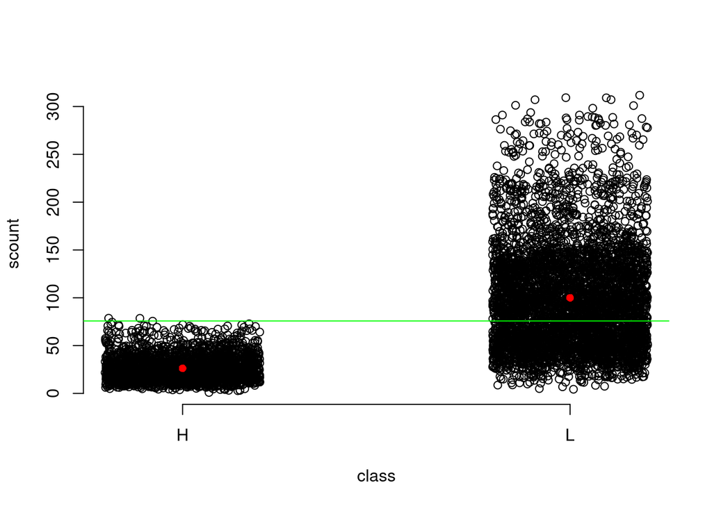

```r
plot(scount ~ jitter(as.numeric(factor(class))), test,
     xlab="class", axes=FALSE)
axis(2)
axis(1, at=as.numeric(unique(factor(test$class))),
     label=unique(factor(test$class)))
abline(h=smean, col="green")
points(as.numeric(unique(factor(test$class))),
       predict(lmfit1, data.frame(class=unique(factor(test$class)))),
       pch=16, col="red")
```

# Summary

In this lab, we started with bash commands on the directory in our virtual machines at /course/NZTA. This directory included our 31 csv files which we will be using for the rest of the lab. We did operations such as free -g to check RAM, and du to see sizes of the files/directories.

We then used the 1st csv file, 20130101_20130331_TMSTrafficQuarterHour.csv to see the sizes of dataframes and data tables it would create. We used profmem() to profile the memory allocation of different methods, including shell script. We measured the memory allocation of creating new dataframes (dailyCountsDF) and memory usage of fitting models.